# Lab8

jche827

3/10/2021

# The Data Set

The data source for this lab is from UCI Machine Learning Repository. The data is a biomedical data set built by Dr. Henrique da Mota. The data have been organized in two different but related classification tasks. The first task consists in classifying patients as belonging to one out of three categories: Normal (100 patients), Disk Hernia (60 patients) or Spondylolisthesis (150 patients). For the second task, the categories Disk Hernia and Spondylolisthesis were merged into a single category labelled as ‘abnormal’. Thus, the second task consists in classifying patients as belonging to one out of two categories: Normal (100 patients) or Abnormal (210 patients). We are using the Vertebral Column data set.

# Import

```r
vc = read.csv("vertebral-column.csv", stringsAsFactors=TRUE)
head(vc)
```

```
##      pi    pt   lla    ss     pr   gos class
## 1 63.03 22.55 39.61 40.48  98.67 -0.25    DH
## 2 39.06 10.06 25.02 29.00 114.41  4.56    DH
## 3 68.83 22.22 50.09 46.61 105.99 -3.53    DH
## 4 69.30 24.65 44.31 44.64 101.87 11.21    DH
## 5 49.71  9.65 28.32 40.06 108.17  7.92    DH
## 6 40.25 13.92 25.12 26.33 130.33  2.23    DH
```

```r
# load libraries
library(MASS)
library(class)
library(gam)
library(nnet)
library(e1071)
library(parallel)
```

# Exploration

## 1. Create a pairwise scatterplot, with observations of different classes shown in different colors.

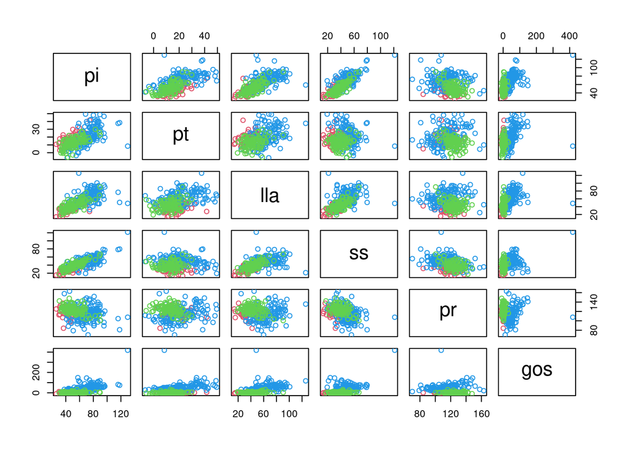

```r
plot(vc[,-7], col=as.numeric(vc[,7])+1)
```

# Classification

## 2. Linear discriminant analysis

```r
(r = lda(class ~ pi + pt + lla + ss + pr + gos, data=vc))
(p1 = predict(r, newdata=vc))
```

```r
yhat1 = p1$class
table(vc$class, yhat1)     # confusion table
```

```
##     yhat1
##       DH  NO  SL
##   DH  39  20   1
##   NO  12  79   9
##   SL   4  11 135
```

```r
(A1 = mean(vc$class == yhat1))    # Classfication accuracy (training/resubstituion)
```

```
## [1] 0.816129
```

Classification accuracy of Linear discriminant analysis: 81.6129%

## 3. Quadratic discriminant analysis

```r
(r2 = qda(class ~ ., data=vc))
(yhat2 = predict(r2, newdata=vc)$class)
```

```r
table(vc$class, yhat2)     # confusion table
```

```
##     yhat2
##       DH  NO  SL
##   DH  42  16   2
##   NO  15  81   4
##   SL   1   1 148
```

```r
(A2 = mean(vc$class == yhat2))    # Classfication accuracy
```

```
## [1] 0.8741935
```

Classification accuracy of Quadratic discriminant analysis: 87.41935%

## 4. Naive Bayes

```r
(r3 = naiveBayes(class ~ ., data=vc))
(yhat3 = predict(r3, newdata=vc))
```

```r
table(vc$class, yhat3)     # confusion table
```

```
##     yhat3
##       DH  NO  SL
##   DH  45  12   3
##   NO  21  69  10
##   SL   0   5 145
```

```r
(A3 = mean(vc$class == yhat3))    # Classfication accuracy
```

```
## [1] 0.8354839
```

Classification accuracy of Naive Bayes: 83.54839%

## 5. Multinomial logistic regression

```r
(r4 = multinom(class ~ ., data=vc))
```

```
## Call:
## multinom(formula = class ~ ., data = vc)
##
## Coefficients:
##    (Intercept)        pi         pt        lla         ss         pr
## NO   -20.23244 -4.584673   4.485069 0.03527065   4.737024 0.13049227
## SL   -21.71458 16.597946 -16.609482 0.02184513 -16.390098 0.07798643
##             gos
## NO -0.005418782
## SL  0.309521250
##
## Residual Deviance: 179.0885
## AIC: 207.0885
```

```r
table(vc$class, predict(r4, vc))    # Confusion table
```

```
##
##       DH  NO  SL
##   DH  40  19   1
##   NO  13  85   2
##   SL   1   3 146
```

```r
A4 = mean(vc$class == predict(r4, vc))   # classification accuracy
```

Classification accuracy of Multinomial logistic regression: 87.41935%

## 6. K -nearest neighbours (with K=10)

```r
set.seed(123)
yhat5 = knn(train=vc[,1:6], test=vc[,1:6], cl=vc[,7], k=10)   # K = 10
table(vc[,7], yhat5)
```

```
##     yhat5
##       DH  NO  SL
##   DH  43  16   1
##   NO  11  87   2
##   SL   1   4 145
```

```r
(A5 = mean(vc$class == yhat5))
```

```
## [1] 0.8870968
```

Classification accuracy of K -nearest neighbours (with K=10): 88.70968%

# Primary Performance Evaluation

## 7. Present your resulting classification accuracy for all five classification methods in a table

```r
t <- matrix(c(A1, A2, A3, A4, A5), ncol=1)
colnames(t) <- c("Classification Accuracy")
rownames(t) <- c("Linear discriminant analysis", "Quadratic discriminant analysis", "Naive Bayes", "Multinomial logistic regression", "K -nearest neighbours")
x <- as.table(t)
x
```

```
##                                 Classification Accuracy
## Linear discriminant analysis                  0.8161290
## Quadratic discriminant analysis               0.8741935
## Naive Bayes                                   0.8354839
## Multinomial logistic regression               0.8741935
## K -nearest neighbours                         0.8870968
```

### From this table, what can we say about the relative performance of these methods for the data set?

In my opinion, the relative performance for these models are actually very similar, they all give accuracies around the 80% range. The variance between best and worst accuracies is only around 7%.

# Multiple Logistic Regression and Generalised Additive Models

## 8. Create a response variable from variable class so that both classes DH and SL are relabelled as AB (Abnormal).

```r
vc$class2 <- vc$class
vc$class2 = gsub("DH|SL", "AB", vc$class2)
vc$class2 <- as.factor(vc$class2)
vc = subset(vc, select = -c(class) )
head(vc)
```

```
##      pi    pt   lla    ss     pr   gos class2
## 1 63.03 22.55 39.61 40.48  98.67 -0.25     AB
## 2 39.06 10.06 25.02 29.00 114.41  4.56     AB
## 3 68.83 22.22 50.09 46.61 105.99 -3.53     AB
## 4 69.30 24.65 44.31 44.64 101.87 11.21     AB
## 5 49.71  9.65 28.32 40.06 108.17  7.92     AB
## 6 40.25 13.92 25.12 26.33 130.33  2.23     AB
```

### Use glm() to build a multiple logistic regression model for this new class variable, and compute the confusion matrix and resubstitution classification accuracy

```r
(r6 = glm(class2 ~ ., data=vc, family = binomial))
yhat =  predict(r6, newdata=vc, type="response")
table(vc$class2, ifelse(yhat>=0.5, "NO", "AB"))      # Confusion table
```

```
##
##       AB  NO
##   AB 188  22
##   NO  22  78
```

```r
x <- mean(vc$class2 == ifelse(yhat>=0.5, "NO", "AB"))      # Classification accuracy
x
```

```
## [1] 0.8580645
```

## 9. Use step() to find the AIC-selected model, with backward selection.

```r
r7 = step(r6, type="backward")    # backward selection. Only AIC
```

```
## Start:  AIC=192.13
## class2 ~ pi + pt + lla + ss + pr + gos
```

```
##        Df Deviance    AIC
## - ss    1   178.27 190.27
## - pi    1   178.27 190.27
## - pt    1   178.27 190.27
## - lla   1   178.86 190.86
## <none>      178.13 192.13
## - pr    1   209.31 221.31
## - gos   1   302.31 314.31
```

```
##
## Step:  AIC=190.27
## class2 ~ pi + pt + lla + pr + gos
```

```
##        Df Deviance    AIC
## - lla   1   178.95 188.95
## <none>      178.27 190.27
## - pi    1   189.08 199.08
## - pt    1   202.23 212.23
## - pr    1   209.36 219.36
## - gos   1   303.45 313.45
```

```
##
## Step:  AIC=188.95
## class2 ~ pi + pt + pr + gos
```

```
##        Df Deviance    AIC
## <none>      178.95 188.95
## - pt    1   208.55 216.55
## - pr    1   212.18 220.18
## - pi    1   212.53 220.53
## - gos   1   310.54 318.53
```

```r
summary(r7)
```

```
##
## Call:
## glm(formula = class2 ~ pi + pt + pr + gos, family = binomial,
##     data = vc)
##
## Deviance Residuals:
##      Min        1Q    Median        3Q       Max
## -2.21933  -0.37927  -0.03193   0.40184   2.79266
##
## Coefficients:
##              Estimate Std. Error z value Pr(>|z|)
## (Intercept) -15.45723    3.27273  -4.723 2.32e-06 ***
## pi            0.11495    0.02266   5.072 3.94e-07 ***
## pt           -0.18140    0.03784  -4.794 1.63e-06 ***
## pr            0.10895    0.02279   4.780 1.75e-06 ***
## gos          -0.16538    0.02288  -7.227 4.92e-13 ***
## ---
## Signif. codes:  0 '***' 0.001 '**' 0.01 '*' 0.05 '.' 0.1 ' ' 1
##
## (Dispersion parameter for binomial family taken to be 1)
##
##     Null deviance: 389.86  on 309  degrees of freedom
## Residual deviance: 178.95  on 305  degrees of freedom
## AIC: 188.95
##
## Number of Fisher Scoring iterations: 8
```

### Which variables are removed by the AIC?

The lla and ss variable columns were removed by the AIC.

## 10. Extend the AIC-selected model with gam() so that each linear term is replaced with a smoothing spline of 5 degrees of freedom. Take a visual approach to reasonably lower the degrees of freedom in each term.

```r
(r8 = gam(class2 ~ s(pi, 5) + s(pt, 5) + s(pr, 5) + s(gos, 5), data=vc, family=binomial()))
```

```
## Call:
## gam(formula = class2 ~ s(pi, 5) + s(pt, 5) + s(pr, 5) + s(gos,
##     5), family = binomial(), data = vc)
##
## Degrees of Freedom: 309 total; 288.9995 Residual
## Residual Deviance: 149.6359
```

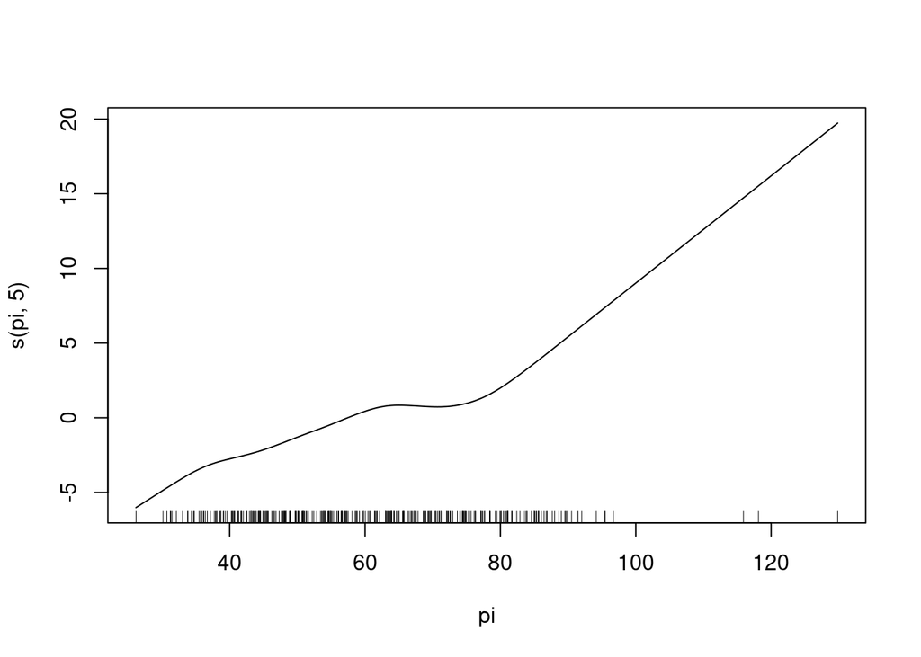

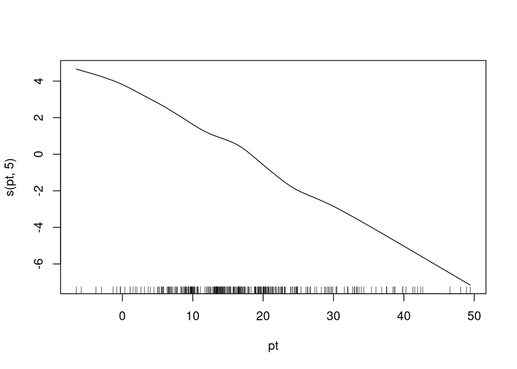

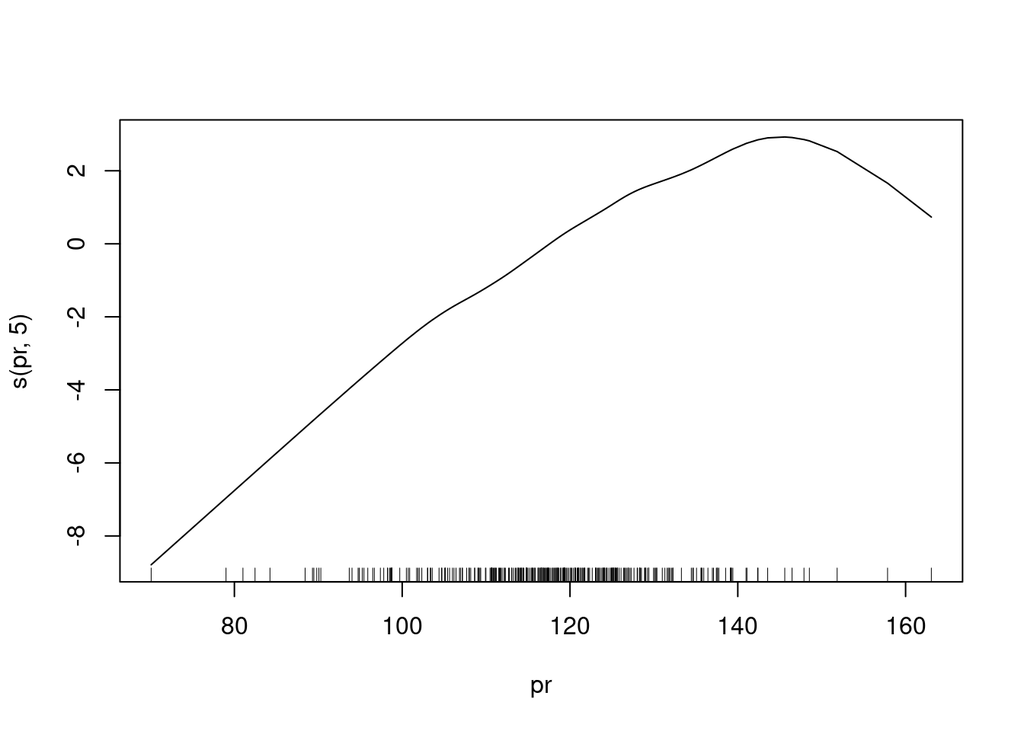

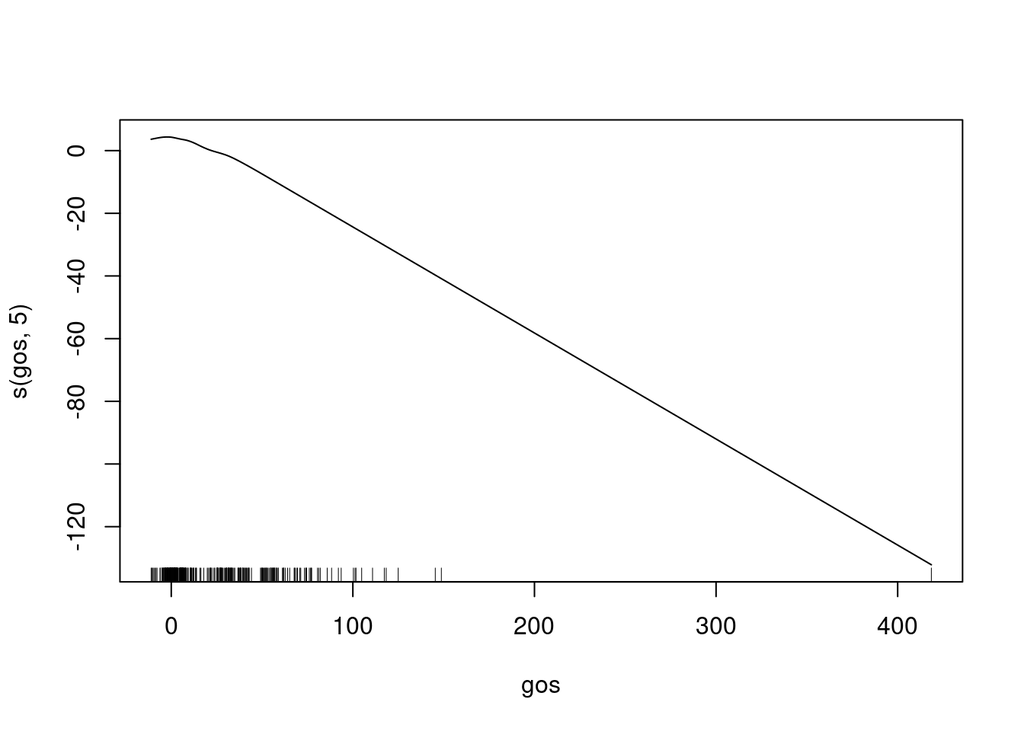

```r
plot(r8)
```

These are the plots before changing the DoF

```r
(r8 = gam(class2 ~ s(pi, 7) + s(pt, 6) + s(pr, 6) + s(gos, 5), data=vc, family=binomial()))
```

```
## Call:
## gam(formula = class2 ~ s(pi, 7) + s(pt, 6) + s(pr, 6) + s(gos,
##     5), family = binomial(), data = vc)
##
## Degrees of Freedom: 309 total; 285.0003 Residual
## Residual Deviance: 143.78
```